# deca_16Smirlyn

Dylan Barth

2025-12-10

## Library rarefaction with mirlyn

Due to high variance in the library sizes, it’s wise to perform repeated rarefactions before downstream processes. To demonstrate this, alpha diversity in a subset of the data is shown before and after rarefaction.

The trick to this piece of the analysis is managing your CPU cores and memory closely, as the only software that does rarefaction correctly is poorly optimized for scaling. Keep an eye on the activity of the script while it is running with ‘htop’.

```r
#import data
ps <- t(readRDS('data/16Sdada2/phyloseq_dada2.rds'))
meta <- data.frame(sample_data(ps))
```

## Choose a rarefaction threshold

Choosing a rarefaction threshold is a critical part of this analysis. It’s ideal to choose a threshold that doesn’t exclude too many samples, since any samples with a library lower than the threshold will be discarded. But choosing too low of a threshold will underestimate the diversity of certain large libraries. It is *very important* to mind the resource usage when running this code, as it has crashed our HPC before. Watch RAM and CPU usage which are modulated by the number of replications (`rep`) and the number of cores used (`mc.cores`) respectively.

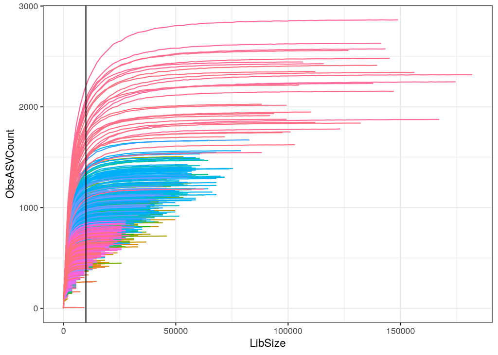

```r
thresh <- 10000
whole_rep <- rarefy_whole_rep(ps, rep = 10, mc.cores=80)
rarecurve(whole_rep, sample = "Sample") + geom_vline(aes(xintercept=thresh)) + theme(legend.position="none")
```

## Perform multiple rarefaction

After choosing the threshold, use mirlyn to perform repeated rarefactions. This produces a very large data product containing `mrep` number of phyloseq objects, each with uniform library sizes of size `thresh`. This data product will be useful for downstream analysis, but is ~15Gb large, so be careful opening it on a laptop.

```r
mrep <- 50
mrare <- mirl(ps, libsize=thresh, rep=mrep, replace=F, mc.cores=80)
saveRDS(mrare, 'data/mirlyn/mirl.rds') ##save

##check for uniformity of sampling size
print('Library size distribution') #should be all 'thresh' size
```

```
## [1] "Library size distribution"
```

```r
summary( sample_sums(mrare[[1]]) )
```

```
##    Min. 1st Qu.  Median    Mean 3rd Qu.    Max.
##   10000   10000   10000   10000   10000   10000
```

```r
##look at some quick examples
print('Rep 10 Subset')
```

```
## [1] "Rep 10 Subset"
```

```r
head(otu_table( subset_samples(mrare[[10]],  (SampleDate  == "Aug_2023") & (Microhabitat == "SSG") ) )[,1:5] )
```

```
## OTU Table:          [6 taxa and 5 samples]
##                      taxa are rows
##      A23_12SSG_S369 A23_14SSG_S377 A23_20SSG_S389 A23_29SSG_S401 A23_31SSG_S405
## ASV1            216            118            107             47            495
## ASV2            150              0             64             41             95
## ASV3             62             30            324            112            231
## ASV4             52             56             67             36             77
## ASV5            124             50             65             27             56
## ASV6            122             14             14             22             75
```

```r
print('Rep 50 Subset')
```

```
## [1] "Rep 50 Subset"
```

```r
head(otu_table( subset_samples(mrare[[50]],  (SampleDate  == "Aug_2023") & (Microhabitat == "SSG") ) )[,1:5] )
```

```
## OTU Table:          [6 taxa and 5 samples]
##                      taxa are rows
##      A23_12SSG_S369 A23_14SSG_S377 A23_20SSG_S389 A23_29SSG_S401 A23_31SSG_S405
## ASV1            219            109            105             45            500
## ASV2            148              0             60             44             93
## ASV3             58             37            329            102            219
## ASV4             46             54             67             33             88
## ASV5            133             51             62             35             54
## ASV6            124             16             12             24             78
```

## Calculate mean alpha diversity in each sample

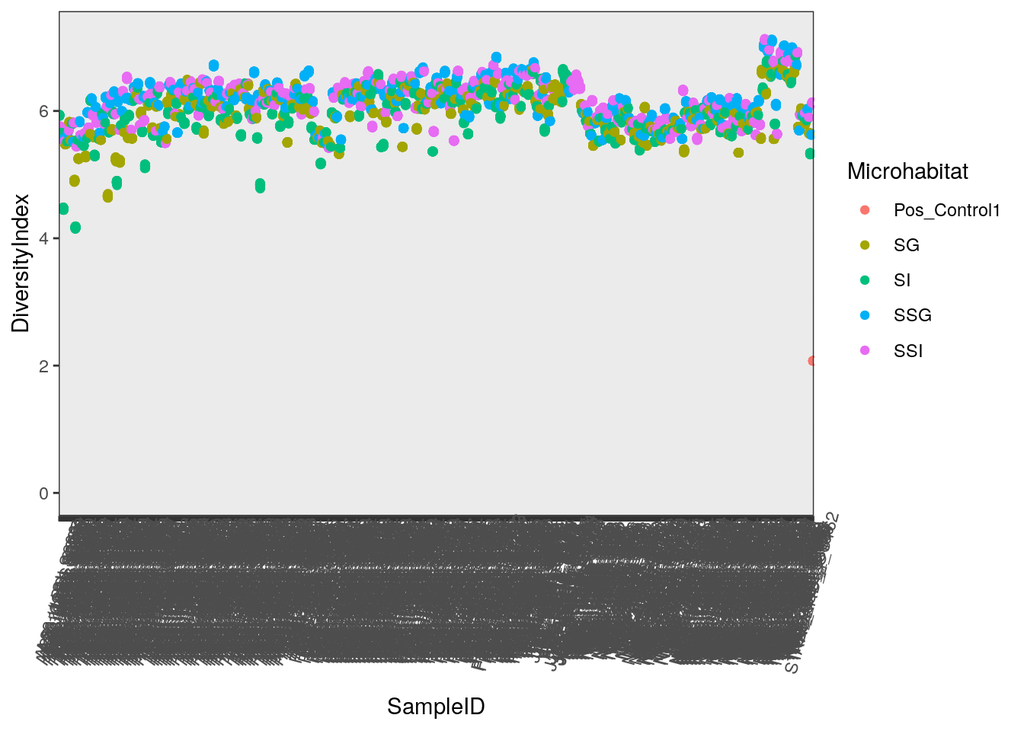

```r
alphadiv_df <- alphadivDF(mrare,diversity = "shannon")
galpha <- alphawichVis(alphadiv_df, xvar = "SampleID", colorvar = "Microhabitat") +
  theme(axis.text.x = element_text(angle=75, vjust = 0.7, hjust = .6))
##entire dataset alpha values
galpha
```

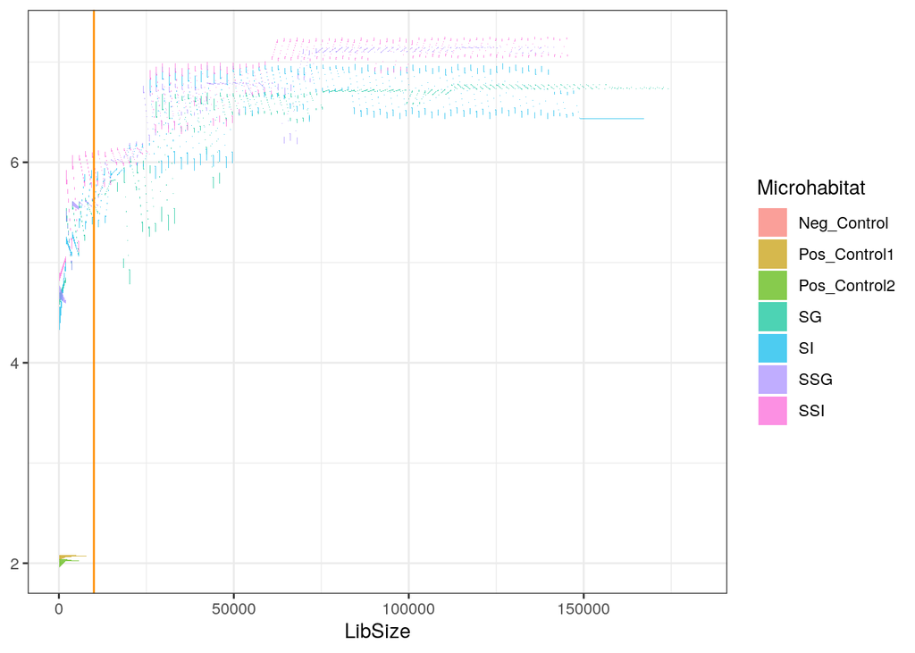

```r
##alpha cone
acone <- alphacone(ps, rep=5, diversity = "shannon", replace=F, mc.cores=40)
gcone <- alphaconeVis(acone, cols = "Microhabitat") + geom_vline(aes(xintercept=thresh), color='darkorange')
gcone #habitat gcone
```

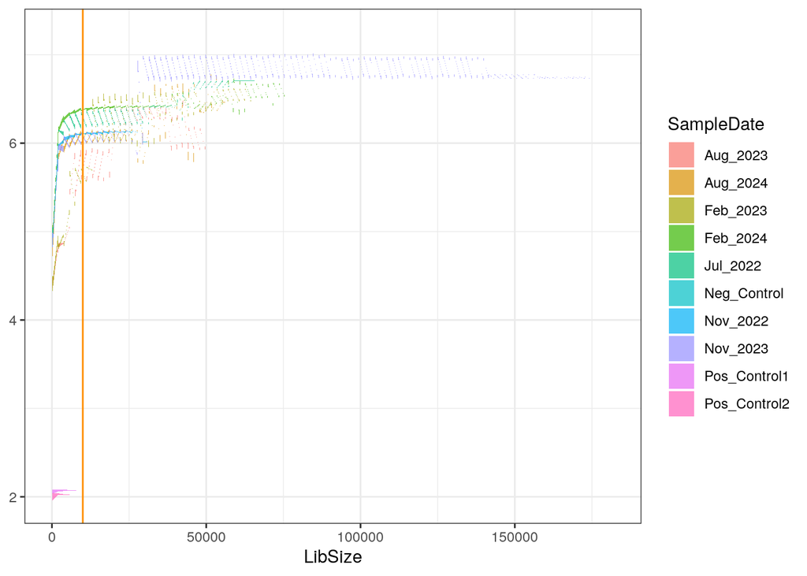

```r
gcone <- alphaconeVis(acone, cols = "SampleDate") + geom_vline(aes(xintercept=thresh), color='darkorange')
gcone #timepoint gcone
```

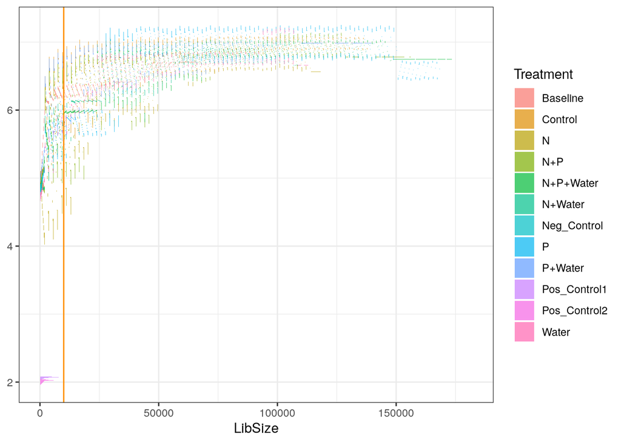

```r
gcone <- alphaconeVis(acone, cols = "Treatment") + geom_vline(aes(xintercept=thresh), color='darkorange')
gcone #treatment gcone
```

```r
saveRDS(alphadiv_df, 'data/mirlyn/rare_alpha.rds')
```

## Un-rarefied alpha diversity

To visualize the difference in rarefied alpha diversities, first we graph the same statistic (shannon alpha diversity) with no rarefaction.

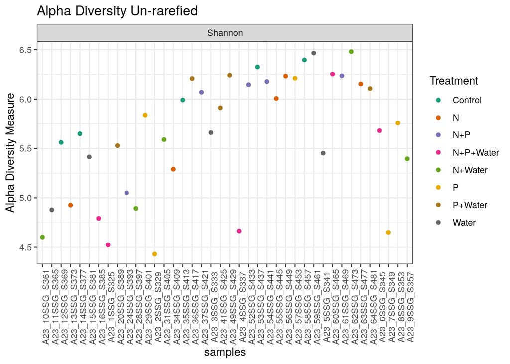

```r
subset <- subset_samples(ps,  (SampleDate  == "Aug_2023") & (Microhabitat == "SSG") )
plot_richness(subset, color='Treatment', measures='Shannon') +
  theme_bw() +
  theme(axis.text.x = element_text(angle=90)) +
  scale_color_brewer(palette = 'Dark2')+
  ggtitle('Alpha Diversity Un-rarefied')
```

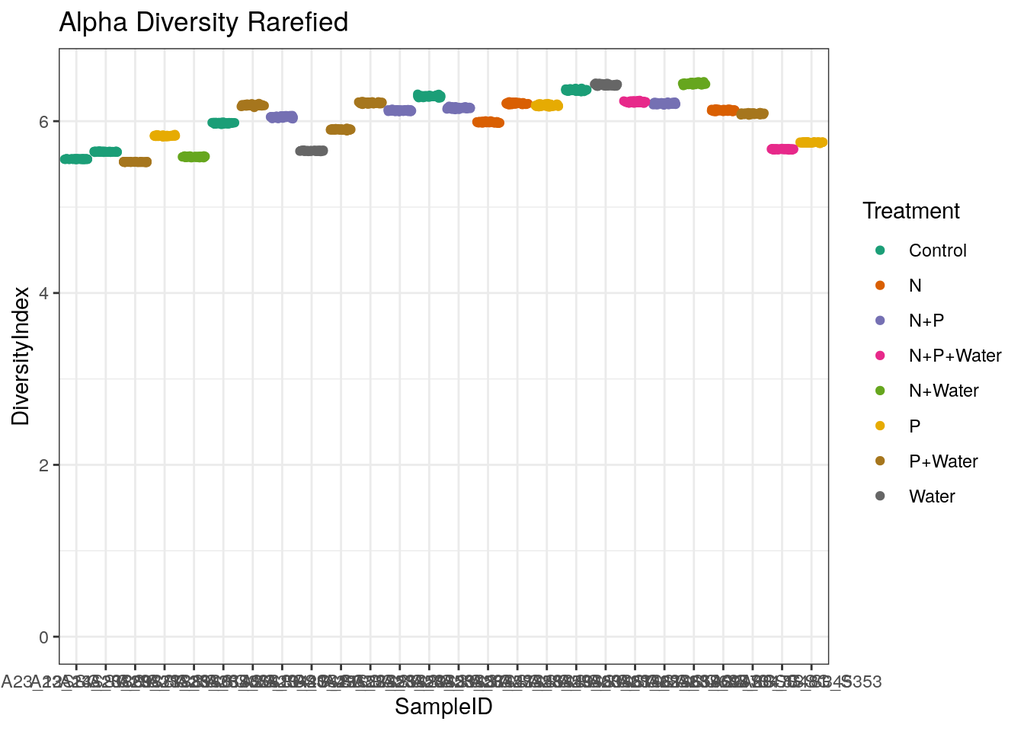

```r
tmp <- list()
for (i in 1:mrep){ #iter through mreps and subsample to match above
  tmp[[i]] <- subset_samples(mrare[[i]],  (SampleDate  == "Aug_2023") & (Microhabitat == "SSG") )
}
alphadiv_df <- alphadivDF(tmp,diversity = "shannon")
galpha <- alphawichVis(alphadiv_df, xvar = "SampleID", colorvar = "Treatment") +
  theme(axis.text.x = element_text(angle=75, vjust = 0.7, hjust = .6)) +
  scale_color_brewer(palette = 'Dark2')+
  theme_bw() +
  ggtitle('Alpha Diversity Rarefied')
##subset alpha values
galpha
```